# kaggle korea 2nd competition 집값 예측

SEO_DJ

2019년 4월 15일

kaggle korea 2nd competition  
https://www.kaggle.com/erikbruin/house-prices-lasso-xgboost-and-a-detailed-eda  
위의 커널을 많이 참조하여 코드를 작성하였습니다.

**Competition background** 내 집 마련의 꿈은 누구나 가지고 있습니다. 하지만 집의 가격은 누구나 알고 있지는 않죠. 집의 가격은 주거 공간의 면적, 위치, 경관, 건물의 연식 등 여러 가지 복잡한 요인의 조합에 의해 결정됩니다. 이번에 분석하실 데이터는 20개의 변수를 가지고 있으며, 어떤 조건을 가진 집의 가격이 높고 낮은지를 예측하는 모델을 만드는 것을 목표로 합니다. 이번 대회는 리더보드 점수뿐만 아니라 캐글의 공유 정신의 기본인 커널 작성을 장려하는 목표를 가지고 있습니다.

# load library & Data

## Load library

```r
library(xgboost)
library(tidyverse)
library(corrplot)
library(gridExtra)
library(caret)
library(e1071)
```

## Load Data and simple processing

train 15035 row 21개의 column  
test 6468개의 row 20개의 column

```r
train <- read.csv("D:\\공모전\\2019 2nd ML month with KaKR\\train.csv",stringsAsFactors = F)
test<-read.csv("D:\\공모전\\2019 2nd ML month with KaKR\\test.csv",stringsAsFactors = F)
list(train = dim(train), test = dim(test))
```

```
## $train
## [1] 15035    21
##
## $test
## [1] 6468   20
```

id 정보를 따로 저장해두고 데이터셋에서 지운다.

```r
test_id <- test$id
train_id <- train$id
test$id <- NULL
train$id <- NULL
test$price <- NA
all <- rbind(train, test)
dim(all)
```

```
## [1] 21503    20
```

–date 날짜 변환이 필요해 보인다.  
–waterfront, view, condition, grade … 등 몇개의 변수들은 factor형으로 변환이 필요하다.

```r
str(all)
```

```
## 'data.frame':    21503 obs. of  20 variables:
##  $ date         : chr  "20141013T000000" "20150225T000000" "20150218T000000" "20140627T000000" ...
##  $ price        : num  221900 180000 510000 257500 291850 ...
##  $ bedrooms     : int  3 2 3 3 3 3 2 3 3 5 ...
##  $ bathrooms    : num  1 1 2 2.25 1.5 2.5 1 1 1.75 2 ...
##  $ sqft_living  : int  1180 770 1680 1715 1060 3560 1160 1430 1370 1810 ...
##  $ sqft_lot     : int  5650 10000 8080 6819 9711 9796 6000 19901 9680 4850 ...
##  $ floors       : num  1 1 1 2 1 1 1 1.5 1 1.5 ...
##  $ waterfront   : int  0 0 0 0 0 0 0 0 0 0 ...
##  $ view         : int  0 0 0 0 0 0 0 0 0 0 ...
##  $ condition    : int  3 3 3 3 3 3 4 4 4 3 ...
##  $ grade        : int  7 6 8 7 7 8 7 7 7 7 ...
##  $ sqft_above   : int  1180 770 1680 1715 1060 1860 860 1430 1370 1810 ...
##  $ sqft_basement: int  0 0 0 0 0 1700 300 0 0 0 ...
##  $ yr_built     : int  1955 1933 1987 1995 1963 1965 1942 1927 1977 1900 ...
##  $ yr_renovated : int  0 0 0 0 0 0 0 0 0 0 ...
##  $ zipcode      : int  98178 98028 98074 98003 98198 98007 98115 98028 98074 98107 ...
##  $ lat          : num  47.5 47.7 47.6 47.3 47.4 ...
##  $ long         : num  -122 -122 -122 -122 -122 ...
##  $ sqft_living15: int  1340 2720 1800 2238 1650 2210 1330 1780 1370 1360 ...
##  $ sqft_lot15   : int  5650 8062 7503 6819 9711 8925 6000 12697 10208 4850 ...
```

### Missing data check

test set 의 price를 제외하고는 결측치는 없다.

```r
colSums(is.na(all))
```

```
##          date         price      bedrooms     bathrooms   sqft_living
##             0          6468             0             0             0
##      sqft_lot        floors    waterfront          view     condition
##             0             0             0             0             0
##         grade    sqft_above sqft_basement      yr_built  yr_renovated
##             0             0             0             0             0
##       zipcode           lat          long sqft_living15    sqft_lot15
##             0             0             0             0             0
```

# correlationplot

–변수별로 선형상관계수를 봤더니 sqft_living, grade 가 price랑 높은 상관계수를 가지고 있다.  
–sqft 변수간에 높은 상관계수를 보인다

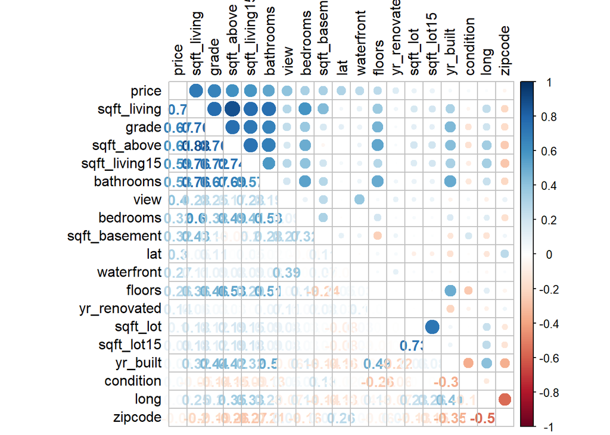

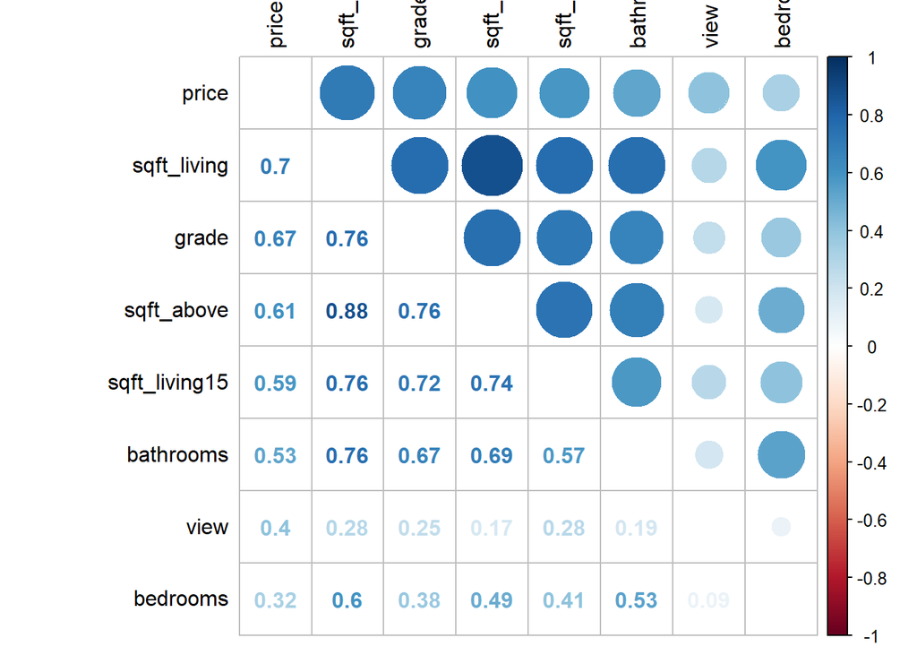

```r
all_numVar<-all %>% filter(!is.na(price)) %>% select(-which(names(all) %in% c("date","days")))
cor_numVar <- cor(all_numVar, use="pairwise.complete.obs") #correlations of all numeric variables
price_cor_sorted_name <- names(sort(-cor_numVar[,'price'])) #sorting by cor value
correlation <- cor_numVar[price_cor_sorted_name,price_cor_sorted_name]
corrplot.mixed(correlation, tl.col="black", tl.pos = "lt")
```

# Variable exploring

```r
custom_boxplot <- function(data_set, factor_variable, response_variable){
  ggplot(data_set , aes(x = as.factor(factor_variable), y = response_variable, fill =as.factor(factor_variable)))+ geom_boxplot() +
    theme(legend.position="none")+
    geom_label(stat = "count", aes(label = ..count.., y = ..count..-..count..+as.integer(min(all$log_price, na.rm = T))), size=4) +
    xlab(deparse(substitute(factor_variable)))+
    ylab(deparse(substitute(response_variable)))
}
#
custom_point <- function(data_set, num_variable, response_variable){
  ggplot(data_set , aes(x = num_variable, y = response_variable)) +
    geom_point(col = "blue", alpha = 0.5) +
    geom_smooth(col = "red1") +
    xlab(deparse(substitute(num_variable)))+
    ylab(deparse(substitute(response_variable)))
}

#
custom_hist <- function(data_set, variable){
  ggplot(data=data_set, aes(x=variable)) +
    geom_histogram(fill="white",colour = "steelblue") +
    geom_density(stat="bin", color = "red", size = .7) +
    xlab(deparse(substitute(variable)))
}

#
set_process <- function(data_set){
  train <- data_set[!is.na(data_set$price),]
  test <- data_set[is.na(data_set$price),]
  return(list(train,test))
}
```

## Price(response variable)

price의 분포가 한 쪽으로 치우쳐저 있다.

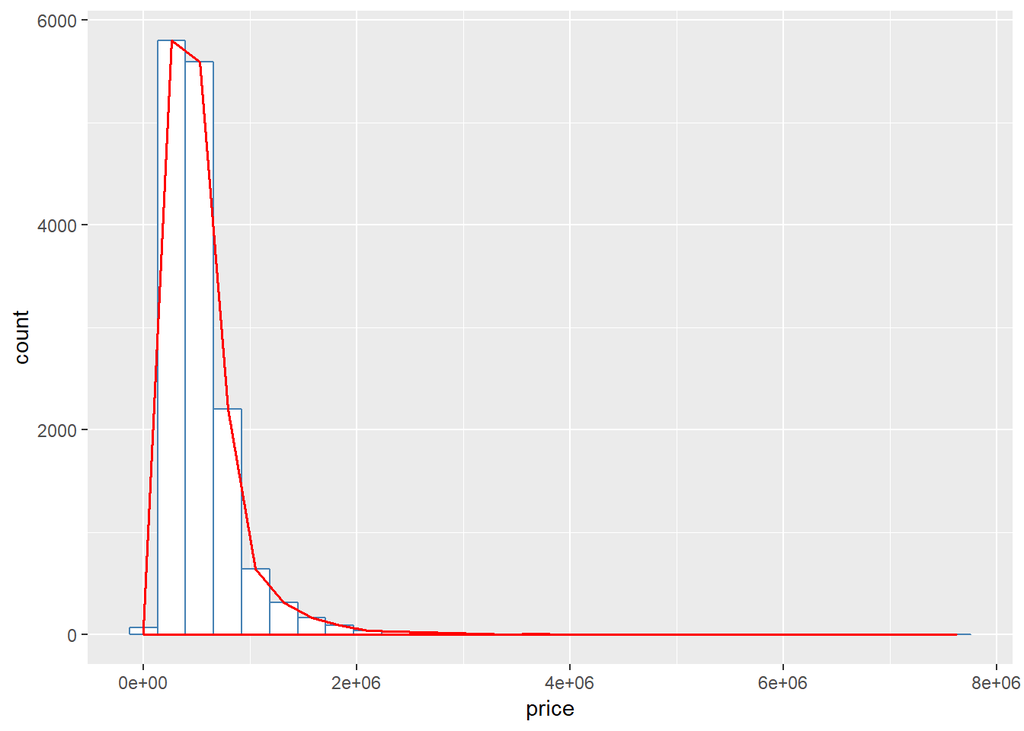

```r
custom_hist(train, train$price) +
  xlab("price")
```

log변환이 좋을것 같아 log변환을 하였더니 분포가 정규분포 같이 변했다.

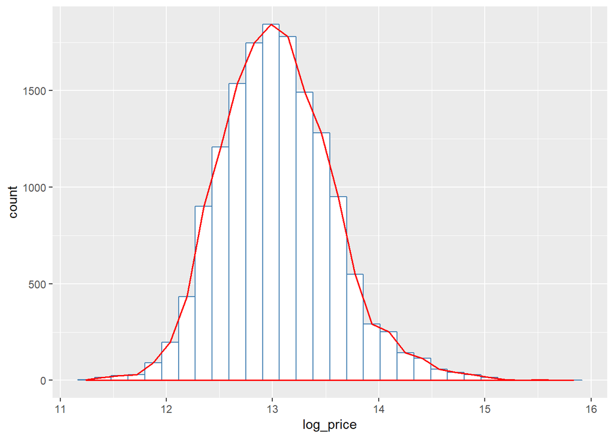

```r
custom_hist(train, log(train$price))+
  xlab("log_price")
```

```r
all <- all %>% mutate(log_price = log(price))
a <- set_process(all);train <- a[[1]]; test <- a[[2]]
```

## sqft_living & sqft_living15

sqft_living & sqft_living15 둘 다 price와 높은 선형관계를 보이고 분포가 한쪽으로 치우쳐있다.  
sqft_living 가 높으면 sqft_living15도 높은 경향보 보인다.  
(8913, 5109번째 열은 sqft_living에 비해 sqft_living이 낮은 값을 보인다.)

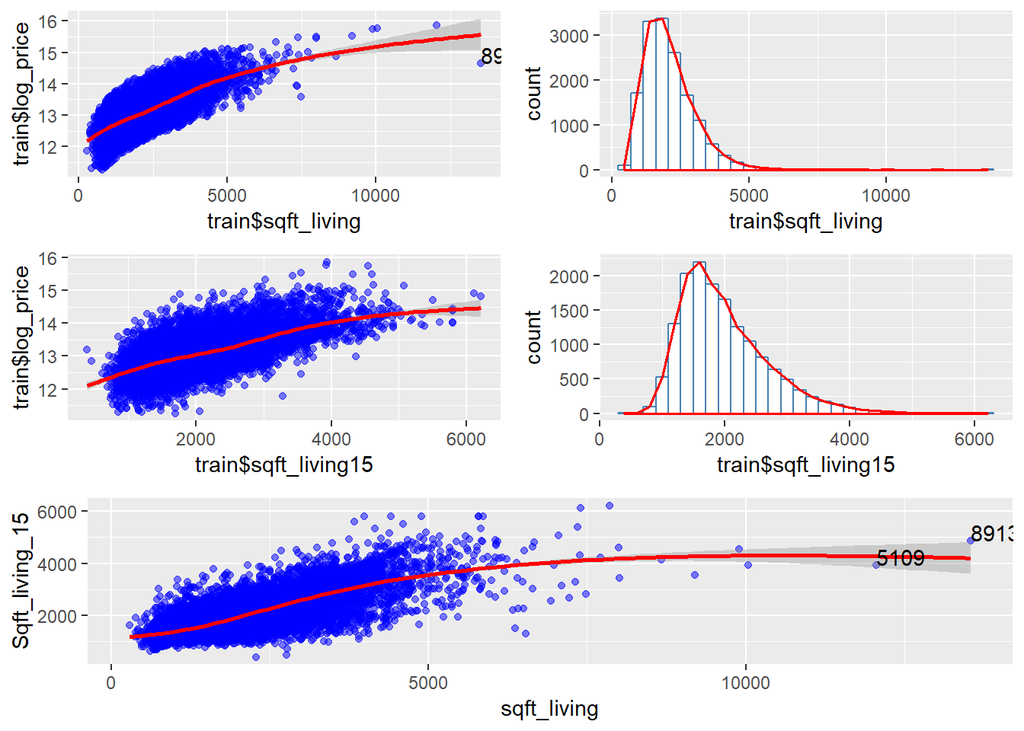

```r
#sqft_living area(numrice variable)
s1 <- custom_point(train, train$sqft_living, train$log_price) +
  geom_text(aes(label=ifelse(all[!is.na(all$log_price),]$sqft_living >  12500,rownames(train),'')),hjust=0,vjust=0)

s2 <- custom_hist(train, train$sqft_living)

s3 <- custom_point(train, train$sqft_living15, train$log_price)

s4 <- custom_hist(train, train$sqft_living15)

s5 <- custom_point(train, train$sqft_living, train$sqft_living15) +
  xlab("sqft_living") +
  ylab("Sqft_living_15") +
  geom_text(aes(label=ifelse((train$sqft_living) > 12000,rownames(train),'')),hjust=0,vjust=0)

grid.arrange(s1,s2,s3,s4, s5, layout_matrix = rbind(c(1,2),c(3,4),c(5,5)))
```

8913 outlier 후보

```r
all[8913,]
```

```
##                 date   price bedrooms bathrooms sqft_living sqft_lot
## 8913 20140505T000000 2280000        7         8       13540   307752
##      floors waterfront view condition grade sqft_above sqft_basement
## 8913      3          0    4         3    12       9410          4130
##      yr_built yr_renovated zipcode     lat     long sqft_living15
## 8913     1999            0   98053 47.6675 -121.986          4850
##      sqft_lot15 log_price
## 8913     217800  14.63969
```

## sqft_lot

sqft_lot & sqft_lot15 이 크다고 집값이 높은지는 잘 모르겠으며  
sqft_lot & sqft_lot15의 분포는 한쪽으로 심하게 치우쳐저있다.

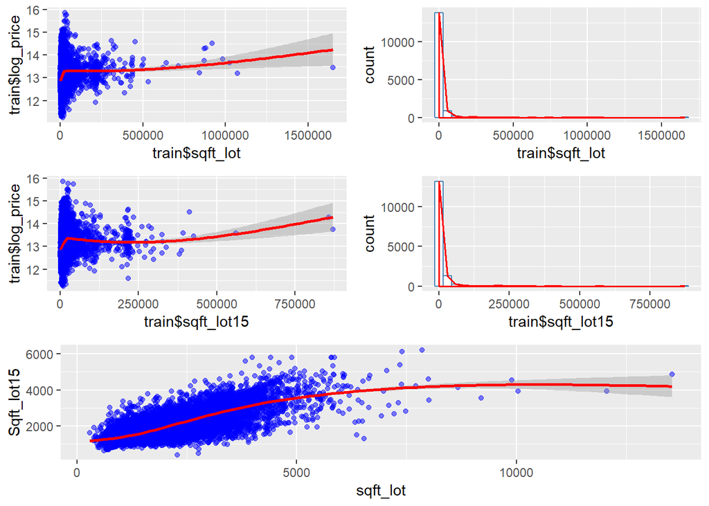

```r
s1 <- custom_point(train, train$sqft_lot, train$log_price)

s2 <- custom_hist(train, train$sqft_lot)

s3 <- custom_point(train, train$sqft_lot15, train$log_price)

s4 <- custom_hist(train, train$sqft_lot15)

s5 <- custom_point(train, train$sqft_living, train$sqft_living15) +
  xlab("sqft_lot") +
  ylab("Sqft_lot15")

grid.arrange(s1,s2,s3,s4, s5, layout_matrix = rbind(c(1,2),c(3,4),c(5,5)))
```

sqft_living이 높다고 sqft_lot이 높은것은 아니다.(15도 마찬가지)

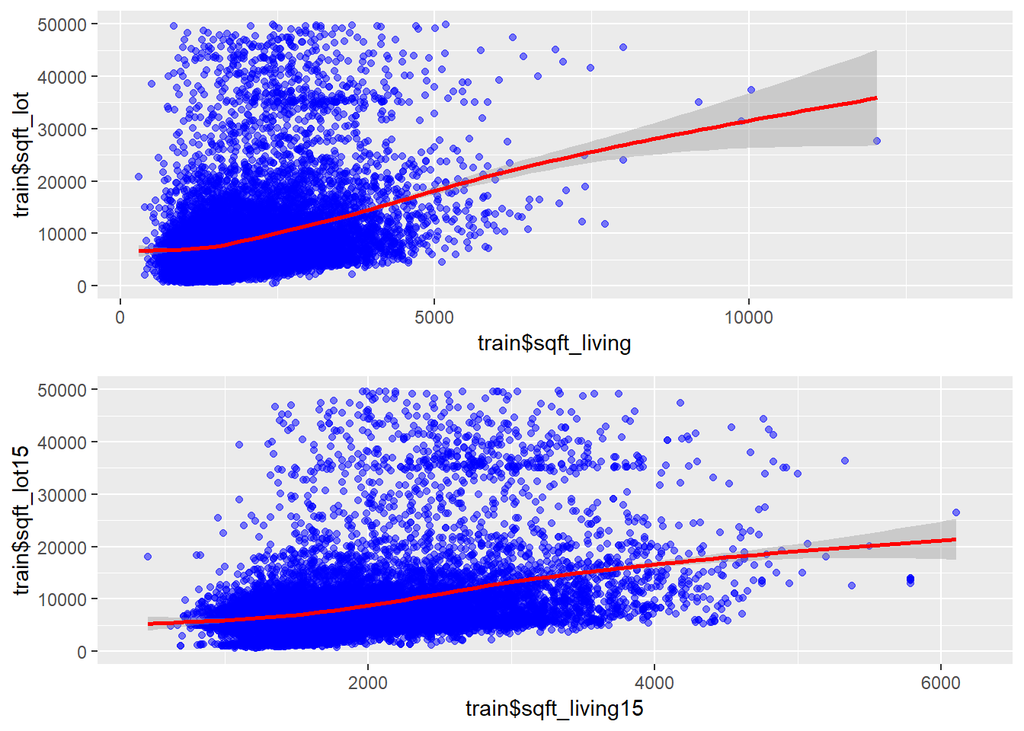

```r
s1 <- custom_point(train, train$sqft_living, train$sqft_lot) +
  ylim(0, 50000)

s2 <- custom_point(train, train$sqft_living15, train$sqft_lot15) +
  ylim(0, 50000)

grid.arrange(s1,s2)
```

## sqft_above

sqft_above도 sqft_living과 마찬가지로 커질수록 높은 집값을 가지고 분포가 한 쪽으로 치우쳐저있다.

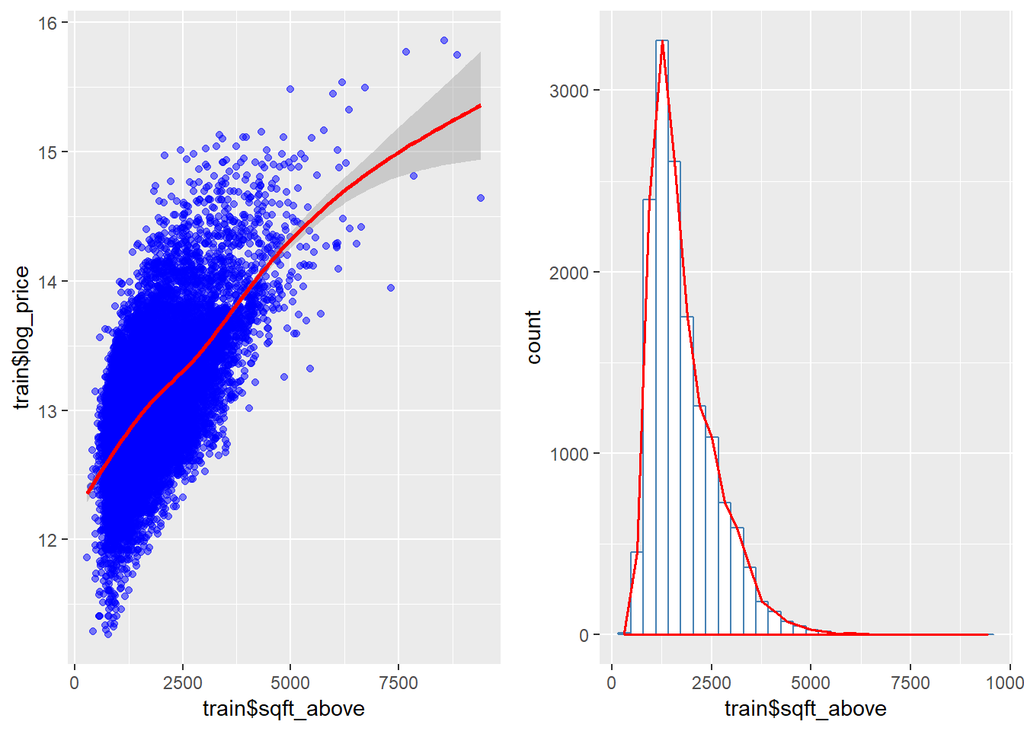

```r
s1 <- custom_point(train, train$sqft_above, train$log_price)

s2 <- custom_hist(train, train$sqft_above)

grid.arrange(s1,s2, ncol = 2)
```

sqft_above sqft_living와 높은 선형관게를 보였다.(0.88)  
그 결과 sqft_living과 sqft_above와 정확히 일치하는 집들이 있었다.

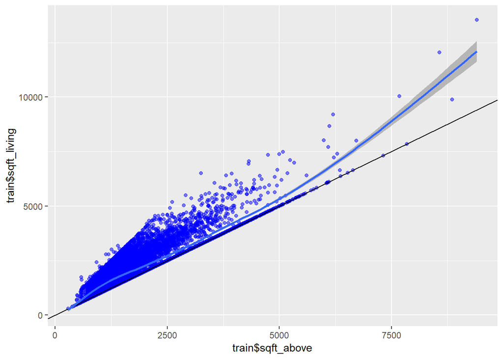

```r
custom_point(train, train$sqft_above, train$sqft_living) +
  geom_abline() +
  geom_smooth(data = NULL)
```

## sqft_basement

sqft_basement와 price와 관계 잘 모르겠다.  
그리고 sqft_basement가 0인 집들이 많이 있다.

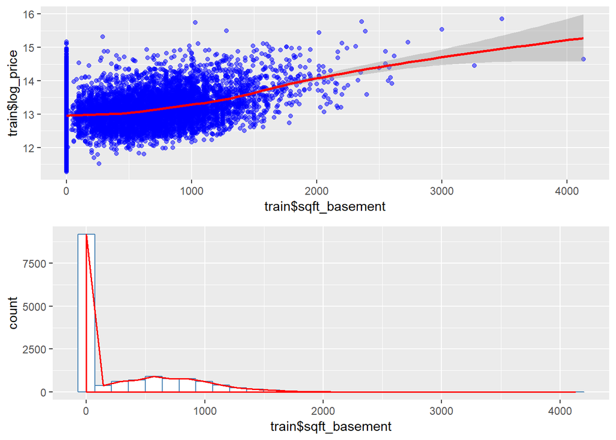

```r
#sqft_basement
s1 <- custom_point(train, train$sqft_basement, train$log_price)

s2<- custom_hist(train, train$sqft_basement)

grid.arrange(s1,s2)
```

sqft_living 와 (sqft_above + sqft_basement)의 correlation값이 1이므로 **sqft_living = sqft_above + sqft_basement**

```r
cor(all$sqft_living, (all$sqft_above+all$sqft_basement))
```

```
## [1] 1
```

sqft_basement 가 0인 집들 basement가 없다고 판단되어 basement의 유무를 판단하는 새로운 feature를 생성하였다.

```r
all<- all %>% mutate(bsmt_is = as.factor(ifelse(all$sqft_basement == 0, 0, 1)))
a <- set_process(all);train <- a[[1]]; test <- a[[2]]
```

basement의 유무에 따라 집값을 본 결과 basement가 있는 집이 좀 더 비싼 집들인 경향이 있었다.

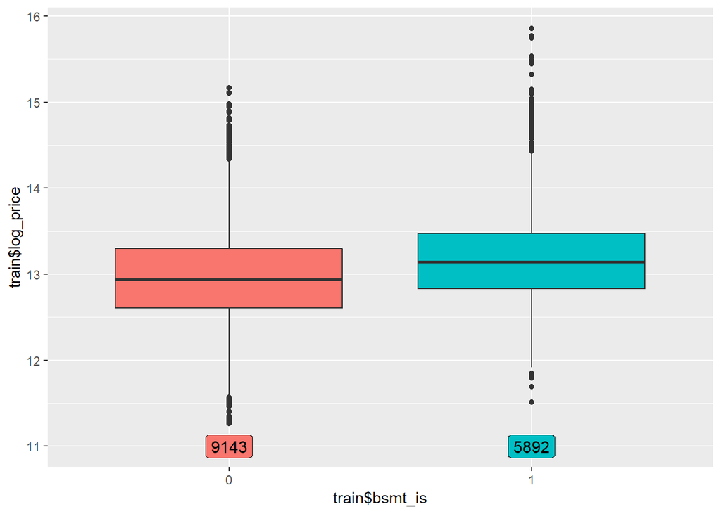

```r
custom_boxplot(train, train$bsmt_is, train$log_price)
```

## grade

grade 별로 집값의 차이가 나는것을 볼 수 있다.  
– grade에 비해 높은 or 낮은 집들이 보인다.(outliers)  
– 1, 2, 3 grade의 집들 거의 없다.

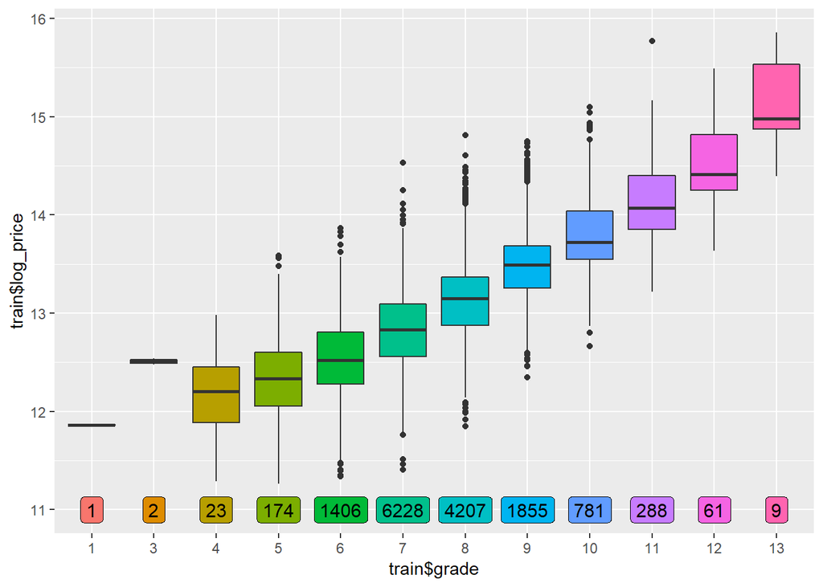

```r
custom_boxplot(train, train$grade, train$log_price)
```

grade에 비해 집값이 낮거나 높은 집들 봤다.

```r
library(kableExtra)
all %>% filter((grade == 11 & log_price >= 15.5) | (grade == 7 & log_price >= 14.5) |
                 (grade == 8 & log_price >= 14.5) | (grade == 7 & log_price <= 11.5)) %>%
  kable() %>% kable_styling()
```

| date | price | bedrooms | bathrooms | sqft_living | sqft_lot | floors | waterfront | view | condition | grade | sqft_above | sqft_basement | yr_built | yr_renovated | zipcode | lat | long | sqft_living15 | sqft_lot15 | log_price | bsmt_is |
| --- | --- | --- | --- | --- | --- | --- | --- | --- | --- | --- | --- | --- | --- | --- | --- | --- | --- | --- | --- | --- | --- |
| 20150511T000000 | 2200000 | 5 | 4.25 | 4640 | 22703 | 2.0 | 1 | 4 | 5 | 8 | 2860 | 1780 | 1952 | 0 | 98052 | 47.6393 | -122.097 | 3140 | 14200 | 14.60397 | 1 |
| 20141212T000000 | 95000 | 2 | 1.00 | 800 | 8550 | 1.0 | 0 | 0 | 3 | 7 | 800 | 0 | 1947 | 0 | 98198 | 47.4075 | -122.294 | 1490 | 8550 | 11.46163 | 0 |
| 20140611T000000 | 7062500 | 5 | 4.50 | 10040 | 37325 | 2.0 | 1 | 2 | 3 | 11 | 7680 | 2360 | 1940 | 2001 | 98004 | 47.6500 | -122.214 | 3930 | 25449 | 15.77031 | 1 |
| 20140813T000000 | 2700000 | 5 | 4.00 | 4230 | 27295 | 2.0 | 1 | 4 | 3 | 8 | 3230 | 1000 | 1949 | 1985 | 98033 | 47.6803 | -122.214 | 2660 | 27295 | 14.80876 | 1 |
| 20140513T000000 | 90000 | 2 | 1.00 | 790 | 2640 | 1.0 | 0 | 0 | 3 | 7 | 790 | 0 | 1973 | 0 | 98034 | 47.7351 | -122.178 | 1310 | 2064 | 11.40756 | 0 |
| 20140825T000000 | 2200000 | 3 | 2.00 | 3570 | 30456 | 1.0 | 0 | 1 | 3 | 8 | 2070 | 1500 | 1946 | 1982 | 98039 | 47.6413 | -122.240 | 3570 | 27418 | 14.60397 | 1 |
| 20150115T000000 | 2050000 | 4 | 3.25 | 3580 | 19989 | 1.5 | 1 | 4 | 4 | 7 | 3480 | 100 | 1915 | 1965 | 98125 | 47.7087 | -122.276 | 2410 | 6389 | 14.53335 | 1 |

```r
#all$grade <- ifelse(all$grade<=3, 4, all$grade)
#all[all$grade <=3,] #2303,4124,13523,15346
```

## Date variable

date 변수를 이용하여 year, month, days변수를 만든다.

```r
all <- all %>% mutate(year = as.numeric(substr(date,1,4))) %>%
  mutate(month = as.numeric(substr(date, 5, 6))) %>%
  mutate(day = as.numeric(substr(date, 7, 8))) %>%
  mutate(days = ifelse(day > 21, "21~31", ifelse(day<=10, "1~10", "11~20")))
a <- set_process(all);train <- a[[1]]; test <- a[[2]]
```

### year

연도별 월별 일별 가격차이가 있는건 같지 않다.  
월별에서 보면 11, 12, 1, 2 (겨울)에 집의 거래량이 적은 경향이 있다.

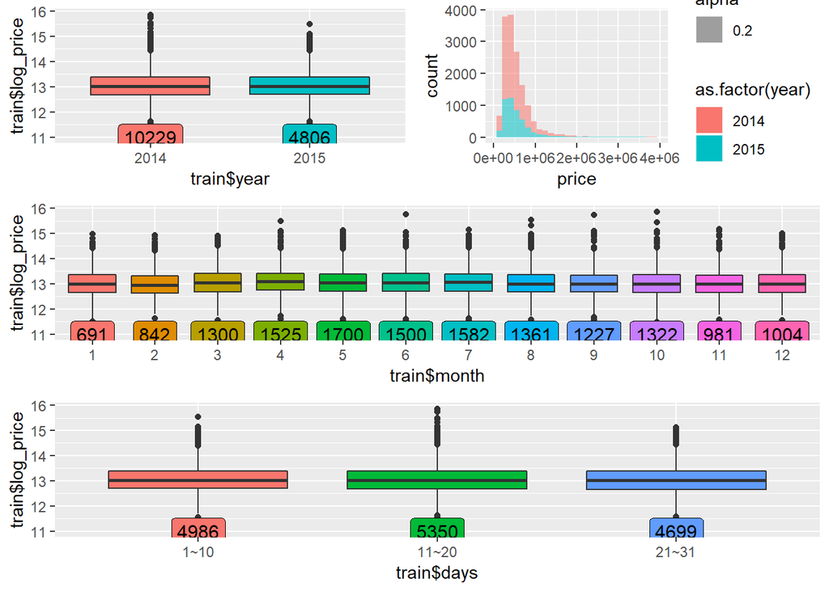

```r
s1 <- custom_boxplot(train, train$year, train$log_price)

s2 <- ggplot(all %>% filter(!is.na(price)) , aes(x=price, fill = as.factor(year), alpha=0.2)) +
  geom_histogram() +
  scale_x_continuous(limits = c(0, 4000000))

s3 <- custom_boxplot(train, train$month, train$log_price)

s4 <- custom_boxplot(train, train$days, train$log_price)

grid.arrange(s1,s2,s3,s4, layout_matrix = rbind(c(1,2),c(3,3),c(4,4)))
```

2014년은 5월~12월 2015년은 1월~5월까지이기 때문에 연도별 거래량 차이가 난다.

```r
all %>% mutate(yr_mo = paste0(year, month)) %>% {table(.$yr_mo)}
```

```
##
## 201410 201411 201412  20145  20146  20147  20148  20149  20151  20152
##   1873   1408   1459   1768   2180   2211   1937   1774    969   1234
##  20153  20154  20155
##   1851   2204    635
```

### seasonal variable 생성

11, 12, 1, 2월에 거래량 적으므로 이 시기에 속하는 변수 생성했다.

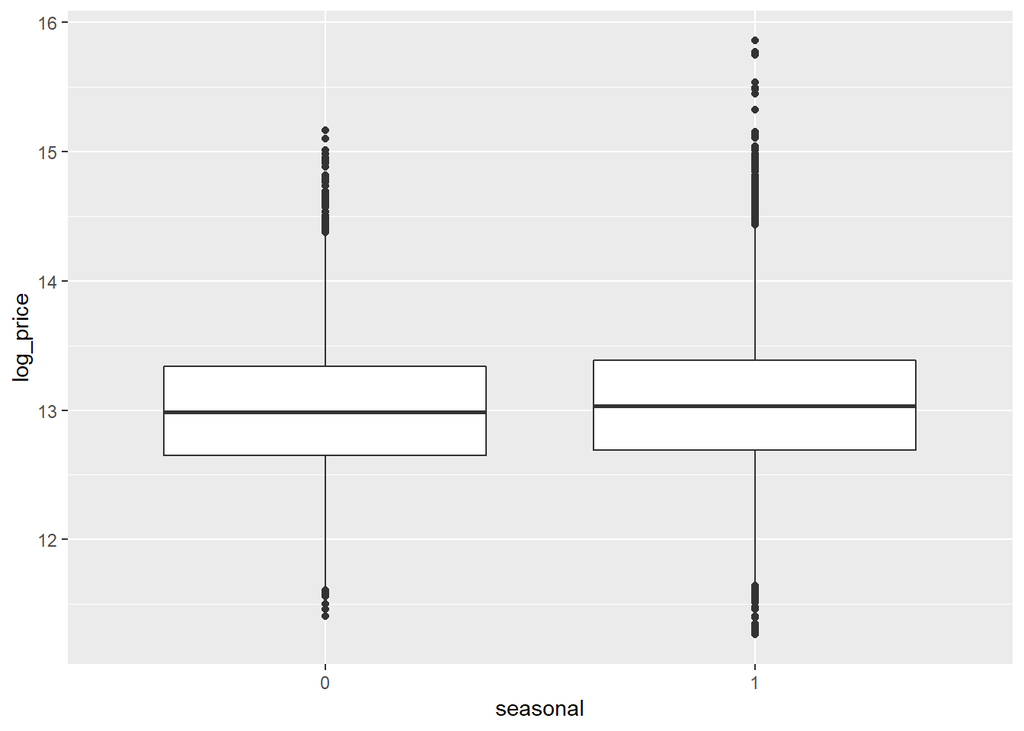

```r
all$seasonal <- as.factor(ifelse(as.character(all$month) %in% c('1','2','11','12'), 0, 1))
ggplot(all, aes(x=seasonal, y=log_price))+
  geom_boxplot()
```

## bedrooms & bathrooms

bedrooms & bathrooms 값이 커질수록 집값비싼 경향이 있다.  
(bedrooms 커질수록 집값에 미치는 영향 작아진다.?)

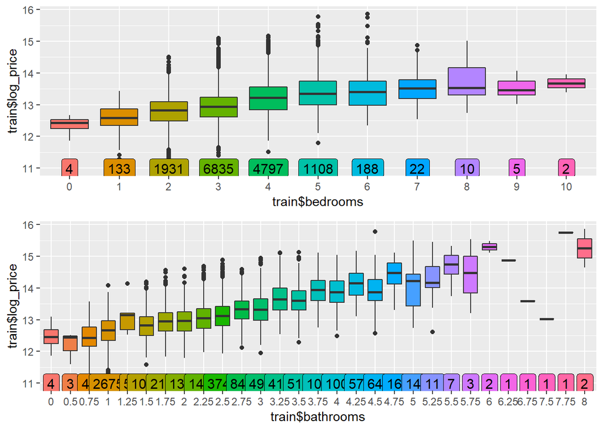

```r
s1 <- custom_boxplot(train, train$bedrooms, train$log_price)

s2 <- custom_boxplot(train, train$bathrooms, train$log_price)

grid.arrange(s1, s2)
```

## View

view가 클수록 price높은 경향이 있다.

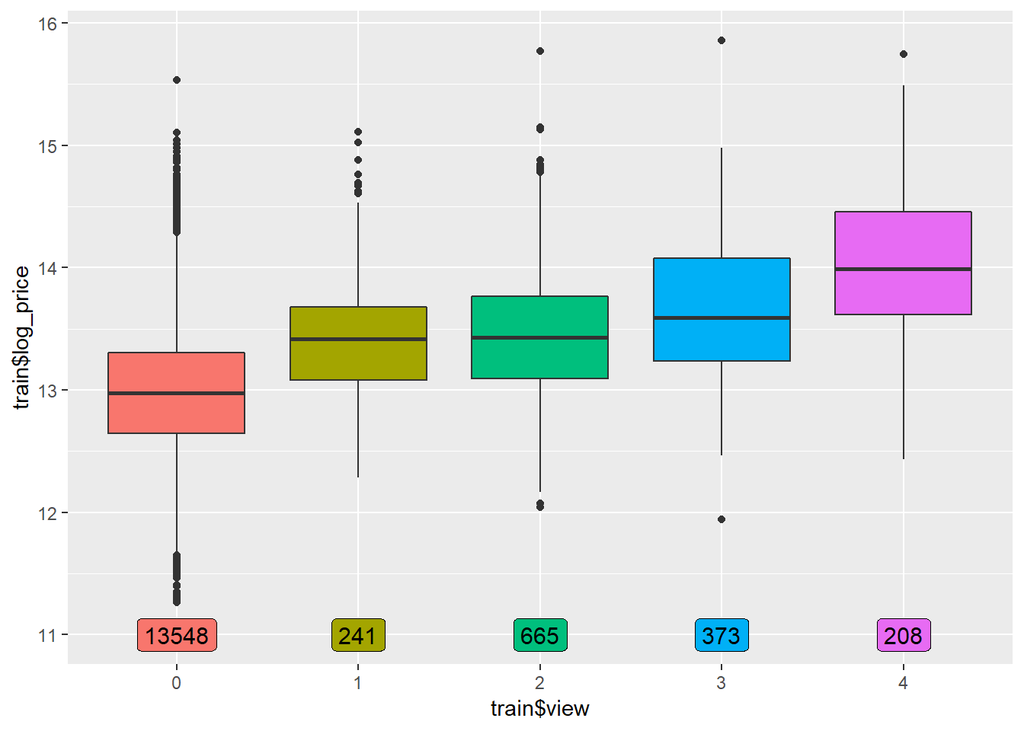

```r
custom_boxplot(train, train$view, train$log_price)
```

## waterfront

waterfront일수록 log_price가 올라간다.

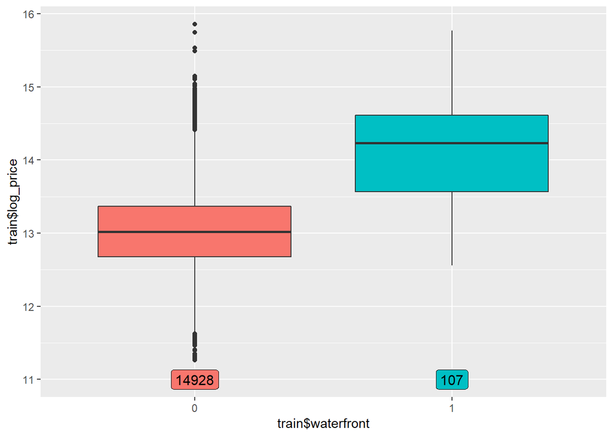

```r
#waterfront
custom_boxplot(train, train$waterfront, train$log_price)
```

waterfront factor 형 자료로 바꿔준다.

```r
all$waterfront <-as.factor(all$waterfront)
```

## floor

floor가 높아진다고 집가격이 높아지는지는 잘 모르겠다.  
1 과 1.5을 비교해보면 1.5가 가격이 높은 집들이 많고 2와 2.5와 비교하면 2.5가 가격이 높은 집들이 많다.  
(.5를 가진 집들은 다락방이 있는것 (https://www.kaggle.com/c/2019-2nd-ml-month-with-kakr/discussion/85011))

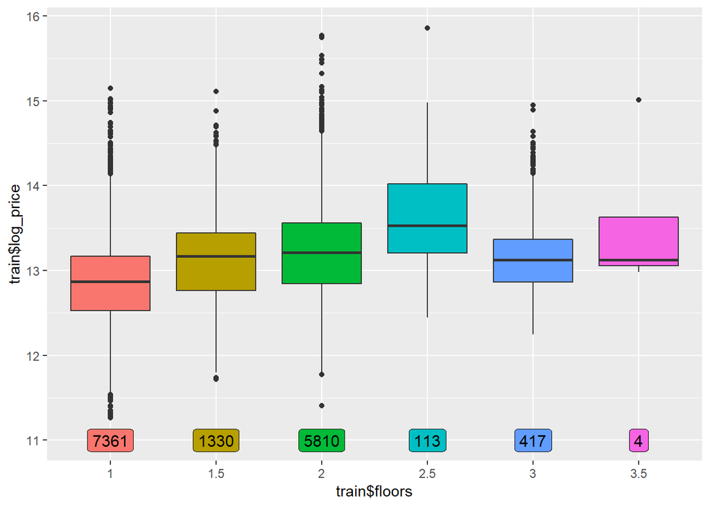

```r
custom_boxplot(train, train$floors, train$log_price)
```

```r
all <- all %>%
  mutate(garret = as.factor(ifelse((floors %% 1) == 0.5, 1, 0))) %>%
  mutate(floors =  as.factor(as.integer(floors%/% 1)))
a <- set_process(all);train <- a[[1]]; test <- a[[2]]
```

## remodeling

yr_renovated가 0인 집들 remodeling하지 않은 집들이라 생각 할 수 있다.

```r
table(all$yr_renovated)
```

```
##
##     0  1934  1940  1944  1945  1946  1948  1950  1951  1953  1954  1955
## 20590     1     2     1     3     2     1     2     1     3     1     3
##  1956  1957  1958  1959  1960  1962  1963  1964  1965  1967  1968  1969
##     3     3     5     1     4     2     4     5     5     2     8     4
##  1970  1971  1972  1973  1974  1975  1976  1977  1978  1979  1980  1981
##     9     2     4     5     3     6     3     8     6    10    10     5
##  1982  1983  1984  1985  1986  1987  1988  1989  1990  1991  1992  1993
##    11    18    18    17    17    18    15    22    25    20    17    19
##  1994  1995  1996  1997  1998  1999  2000  2001  2002  2003  2004  2005
##    19    16    15    15    19    17    35    19    22    36    26    35
##  2006  2007  2008  2009  2010  2011  2012  2013  2014  2015
##    24    35    18    22    18    13    11    37    91    16
```

yr_built 값을 yr_renovated 값이 0이면 yr_built로 0이 아니면 yr_renovated 값으로 대체한다.  
**is_remo : 리모델링을 했는지 여부** 의 변수를 새로 만든다.

```r
all<-all %>% mutate(yr_built = ifelse(yr_renovated == 0, yr_built, yr_renovated)) %>%
  mutate(is_remo = as.factor(ifelse(yr_renovated == 0, 0, 1)))
a <- set_process(all);train <- a[[1]]; test <- a[[2]]
```

remodeling의 여부에 따라 집값의 차이가 좀 있는거 같다.

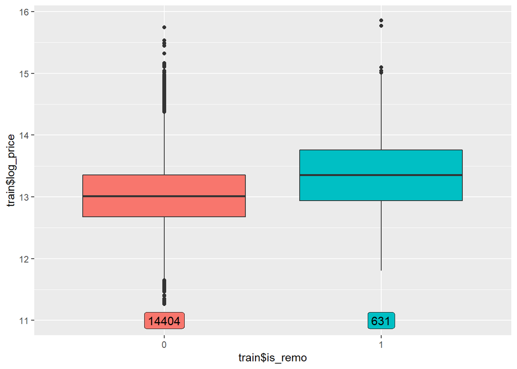

```r
custom_boxplot(train, train$is_remo, train$log_price)
```

## yr_built

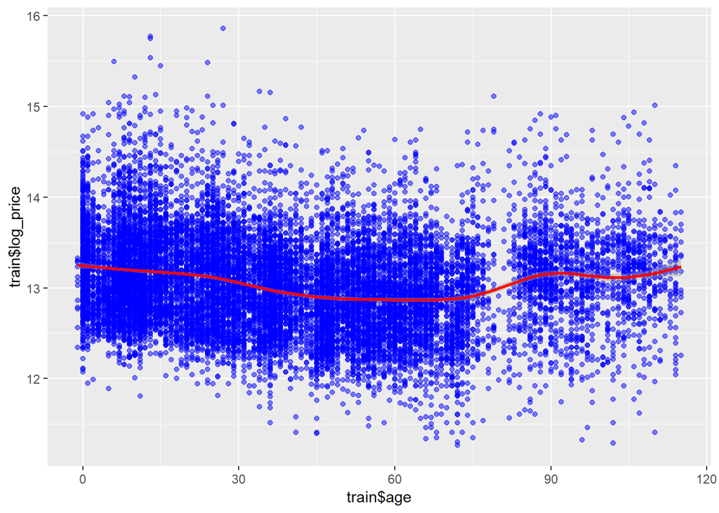

```r
custom_point(train, train$age, train$log_price)
```

## condition

1, 2 값을 가지는 집은 거의 없고 (1, 2), (3, 4, 5) 두 그룹 간의 가격차이는 보이나 그룹내에서 차이는 명확하지 않다.

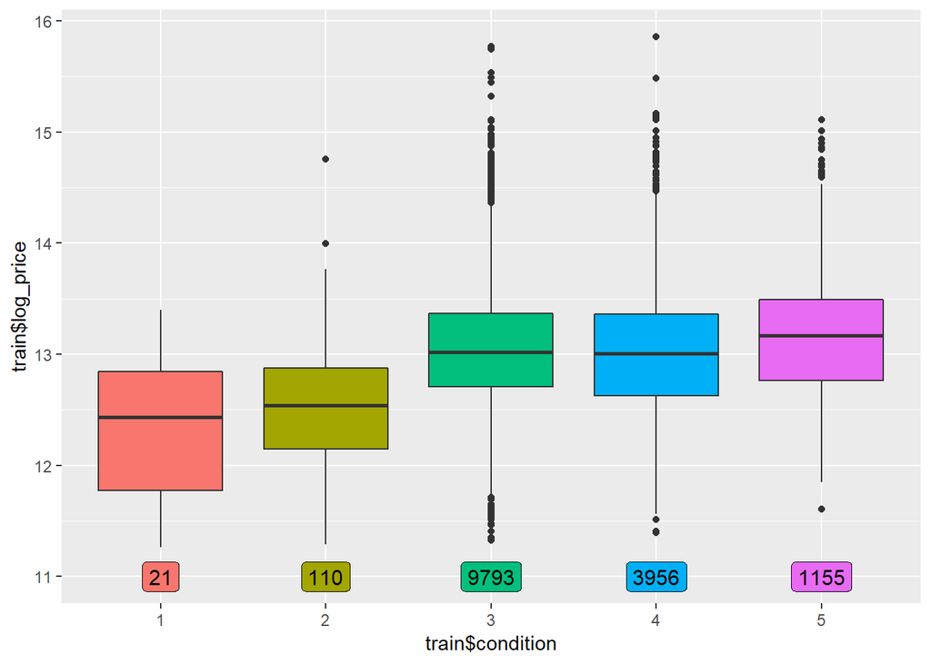

```r
custom_boxplot(train, train$condition, train$log_price)
```

## zipcode

zipcode별로 집값의 가격차이가 나는것을 볼 수 있다.

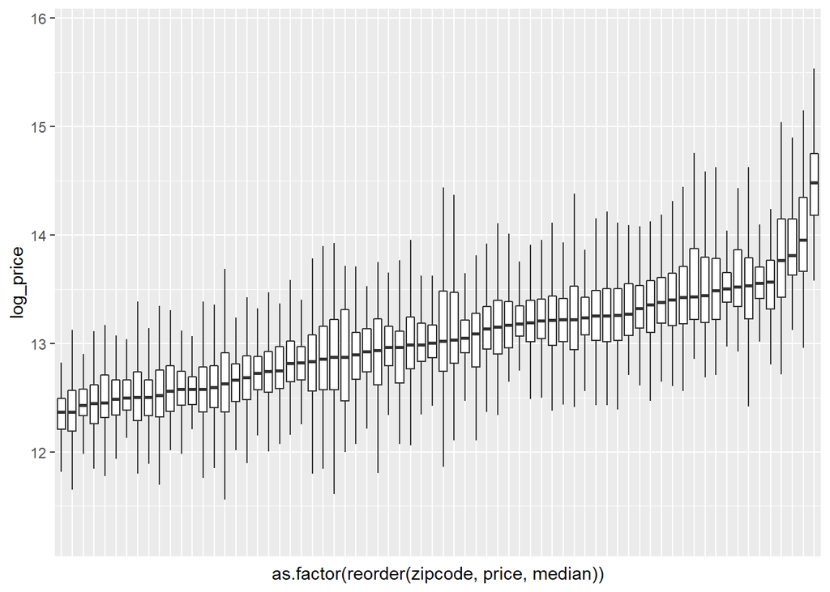

```r
ggplot(all %>% filter(!is.na(price)), aes(x =as.factor(reorder(zipcode, price, median)), y = log_price))  +
  geom_boxplot(outlier.shape = NA) +
  theme(axis.text.x=element_blank(),
        axis.ticks.x=element_blank())
```

```r
#zipcode rank 로 zipcode encding
zipcode_data <- all %>% filter(!is.na(price)) %>%
  group_by(zipcode) %>%
  summarise(median = median(log_price), fst_qrt = quantile(log_price,0.25),
            trd_qrt = quantile(log_price, 0.75)) %>%
  arrange(median)

zipcode_data<-cbind(zipcode_data,c(1:nrow(zipcode_data)))
zipcode_data <- zipcode_data %>% select(c(1,5))
colnames(zipcode_data)[2] <- "zipcode_rank"

all<-left_join(all, as.data.frame(zipcode_data), by = 'zipcode')
all$zipcode <- NULL

all$zip_clst<-NULL
a <- set_process(all);train <- a[[1]]; test <- a[[2]]
```

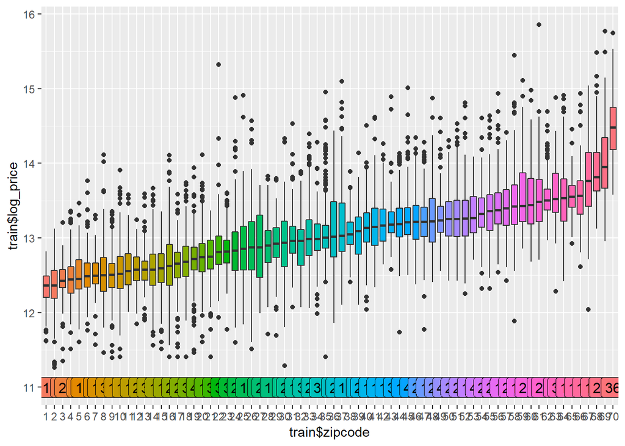

```r
custom_boxplot(train, train$zipcode, train$log_price)
```

# Feature engineering

## eliminate features

```r
str(all)
```

```
## 'data.frame':    21503 obs. of  30 variables:
##  $ date         : chr  "20141013T000000" "20150225T000000" "20150218T000000" "20140627T000000" ...
##  $ price        : num  221900 180000 510000 257500 291850 ...
##  $ bedrooms     : int  3 2 3 3 3 3 2 3 3 5 ...
##  $ bathrooms    : num  1 1 2 2.25 1.5 2.5 1 1 1.75 2 ...
##  $ sqft_living  : int  1180 770 1680 1715 1060 3560 1160 1430 1370 1810 ...
##  $ sqft_lot     : int  5650 10000 8080 6819 9711 9796 6000 19901 9680 4850 ...
##  $ floors       : Factor w/ 3 levels "1","2","3": 1 1 1 2 1 1 1 1 1 1 ...
##  $ waterfront   : Factor w/ 2 levels "0","1": 1 1 1 1 1 1 1 1 1 1 ...
##  $ view         : int  0 0 0 0 0 0 0 0 0 0 ...
##  $ condition    : int  3 3 3 3 3 3 4 4 4 3 ...
##  $ grade        : int  7 6 8 7 7 8 7 7 7 7 ...
##  $ sqft_above   : int  1180 770 1680 1715 1060 1860 860 1430 1370 1810 ...
##  $ sqft_basement: int  0 0 0 0 0 1700 300 0 0 0 ...
##  $ yr_built     : int  1955 1933 1987 1995 1963 1965 1942 1927 1977 1900 ...
```

[output cut: 16 more lines]

– 날짜 자료형 큰 의미 없어보이나 다 지우면 오히려 score가 떨어졌다. 자료가 2014~2015년 사이의 자료이니 연도, 월을 새로 묶어준 변수를 만들고 나머지 날짜 변수 다 제거한다.. – yr_renovated, yr_built 변수는 age와 is_remo를 만드는데 쓰였으므로 필요없다 판단 제거한다.

```r
names(all)
```

```
##  [1] "date"          "price"         "bedrooms"      "bathrooms"
##  [5] "sqft_living"   "sqft_lot"      "floors"        "waterfront"
##  [9] "view"          "condition"     "grade"         "sqft_above"
## [13] "sqft_basement" "yr_built"      "yr_renovated"  "lat"
## [17] "long"          "sqft_living15" "sqft_lot15"    "log_price"
## [21] "bsmt_is"       "year"          "month"         "day"
## [25] "days"          "seasonal"      "garret"        "is_remo"
## [29] "age"           "zipcode_rank"
```

```r
all <- all %>% mutate(yr_mo = paste0(year, month))
all<-all[, -which(names(all) %in% c("date", "price","year","month","days","day","yr_renovated","yr_built"))]
all$yr_mo <- as.factor(all$yr_mo)
```

## make some new features

몇개의 새로운 features들을 만든다.

```r
str(all)
```

```
## 'data.frame':    21503 obs. of  23 variables:
##  $ bedrooms     : int  3 2 3 3 3 3 2 3 3 5 ...
##  $ bathrooms    : num  1 1 2 2.25 1.5 2.5 1 1 1.75 2 ...
##  $ sqft_living  : int  1180 770 1680 1715 1060 3560 1160 1430 1370 1810 ...
##  $ sqft_lot     : int  5650 10000 8080 6819 9711 9796 6000 19901 9680 4850 ...
##  $ floors       : Factor w/ 3 levels "1","2","3": 1 1 1 2 1 1 1 1 1 1 ...
##  $ waterfront   : Factor w/ 2 levels "0","1": 1 1 1 1 1 1 1 1 1 1 ...
##  $ view         : int  0 0 0 0 0 0 0 0 0 0 ...
##  $ condition    : int  3 3 3 3 3 3 4 4 4 3 ...
##  $ grade        : int  7 6 8 7 7 8 7 7 7 7 ...
##  $ sqft_above   : int  1180 770 1680 1715 1060 1860 860 1430 1370 1810 ...
##  $ sqft_basement: int  0 0 0 0 0 1700 300 0 0 0 ...
##  $ lat          : num  47.5 47.7 47.6 47.3 47.4 ...
##  $ long         : num  -122 -122 -122 -122 -122 ...
##  $ sqft_living15: int  1340 2720 1800 2238 1650 2210 1330 1780 1370 1360 ...
##  $ sqft_lot15   : int  5650 8062 7503 6819 9711 8925 6000 12697 10208 4850 ...
##  $ log_price    : num  12.3 12.1 13.1 12.5 12.6 ...
##  $ bsmt_is      : Factor w/ 2 levels "0","1": 1 1 1 1 1 2 2 1 1 1 ...
##  $ seasonal     : Factor w/ 2 levels "0","1": 2 1 1 2 1 2 2 2 2 2 ...
##  $ garret       : Factor w/ 2 levels "0","1": 1 1 1 1 1 1 1 2 1 2 ...
##  $ is_remo      : Factor w/ 2 levels "0","1": 1 1 1 1 1 1 1 1 1 1 ...
##  $ age          : num  59 82 28 19 52 50 72 87 37 115 ...
##  $ zipcode_rank : int  10 34 56 6 8 53 50 34 56 43 ...
##  $ yr_mo        : Factor w/ 13 levels "201410","201411",..: 1 10 10 5 9 12 4 4 1 11 ...
```

```r
all$sqft <- all$sqft_living/all$sqft_lot #토지대비 주거비율
all$sqft_chg <- all$sqft_living - all$sqft_living15 # 15년도 이후 변화?
all$total_rooms <- all$bathrooms + all$bedrooms # 총 방의수
```

## correlationplot again

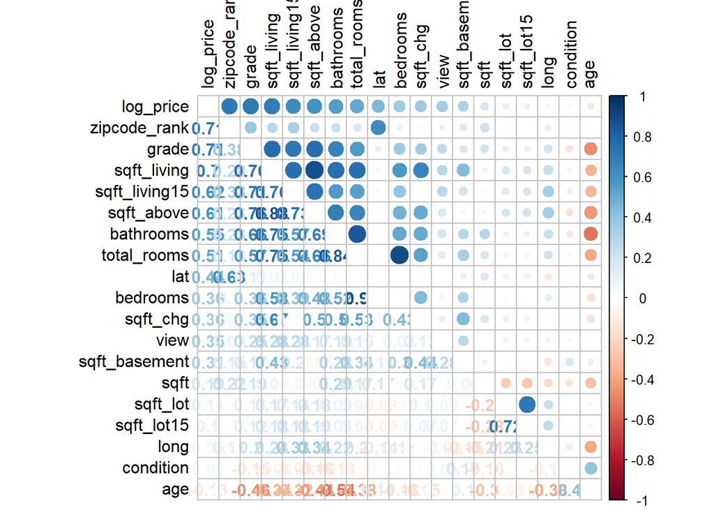

```r
numericVars <- which(sapply(all, is.numeric)) #index vector numeric variables
numericVarNames <- names(numericVars) #saving names vector for use later on
all_numVar <-all[, numericVars] # only numeric column
cor_numVar <- cor(all_numVar, use="pairwise.complete.obs") #correlations of all numeric variables
price_cor_sorted_name <- names(sort(-cor_numVar[,'log_price'])) #sorting by cor value
correlation <- cor_numVar[price_cor_sorted_name,price_cor_sorted_name]
corrplot.mixed(correlation, tl.col="black", tl.pos = "lt")
```

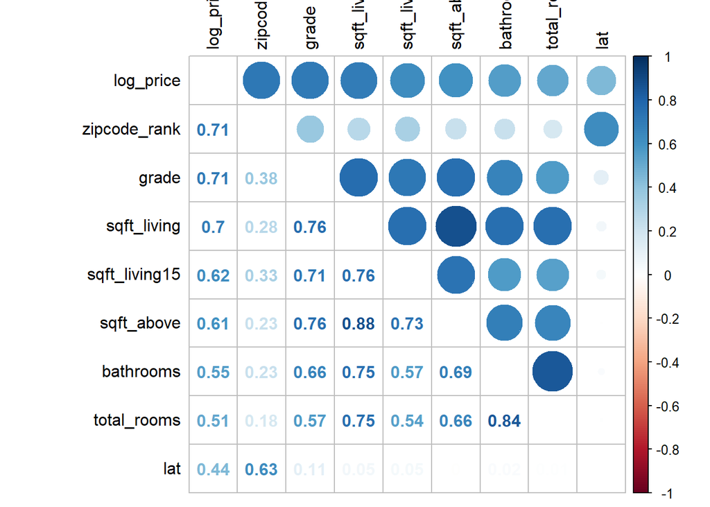

```r
corrplot.mixed(correlation[1:9,1:9], tl.col="black", tl.pos = "lt")
```